# Data Translation Assignment

Cam Nguyen

2022-05-22

The story is that UW and Starbucks are way above their competition as the top brands of the top two industries in King County according to July data. The industries are very different, as shown by the trend of daily visits. By looking into the trends, we notice that Starbucks has more competition. Both companies are way ahead of their competition. Starbucks’ daily visits are a lot more consistent than UW Med and this also shows a contrast in the industry daily visit trends as well.

#### UW Med and Starbucks are the top visited brands of the top industries. They are substantially ahead in average daily visits.

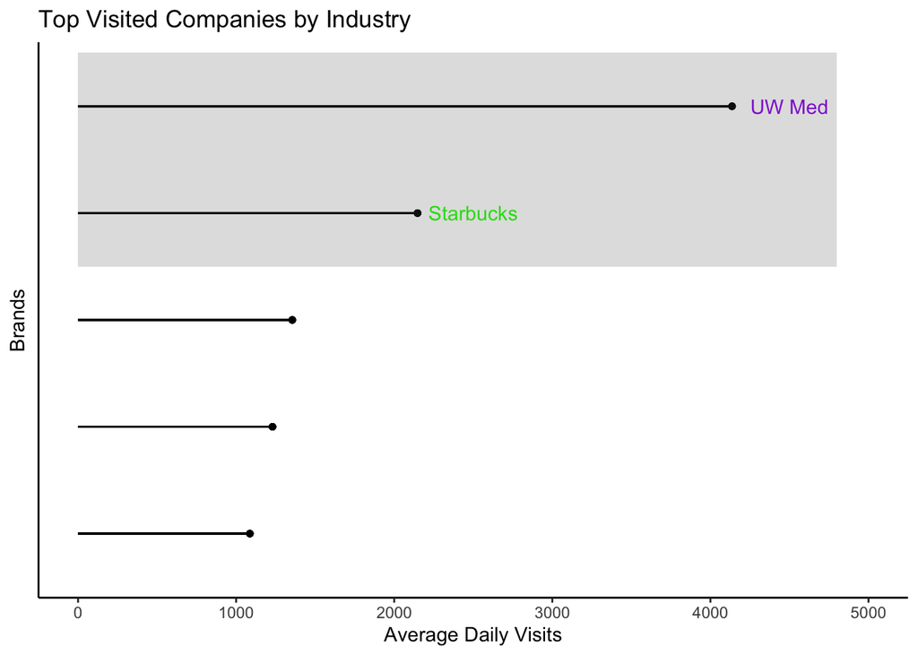

```r
lolli <- dv %>% filter(brands == c('UW Medicine', 'Starbucks','Costco Wholesale Corp.', 'Safeway', 'McDonald\'s'))

ggplot(lolli, aes(y=avr_daily_visits, x = reorder(brands,avr_daily_visits))) + geom_lollipop(show.legend = FALSE) + labs(x = 'Brands', y ='Average Daily Visits') + theme_classic() + coord_flip() + scale_y_continuous(limits = c(0, 5000)) + theme(axis.text.y = element_blank(), axis.ticks.y = element_blank()) + annotate('text', x = 'UW Medicine', y = 4500, label = 'UW Med', color = 'purple') + annotate('text', x = 'Starbucks', y = 2500, label = 'Starbucks', color = 'green') + annotate("rect", xmin = 3.5, xmax = 5.5, ymin = 0, ymax = 4800, alpha = .2) + ggtitle(label = 'Top Visited Companies by Industry')
```

#### Here the graph shows that UW Med and Starbucks are separated from other top brands and are further ahead in daily visits. The line graph shows the difference in consistency of their daily visits.

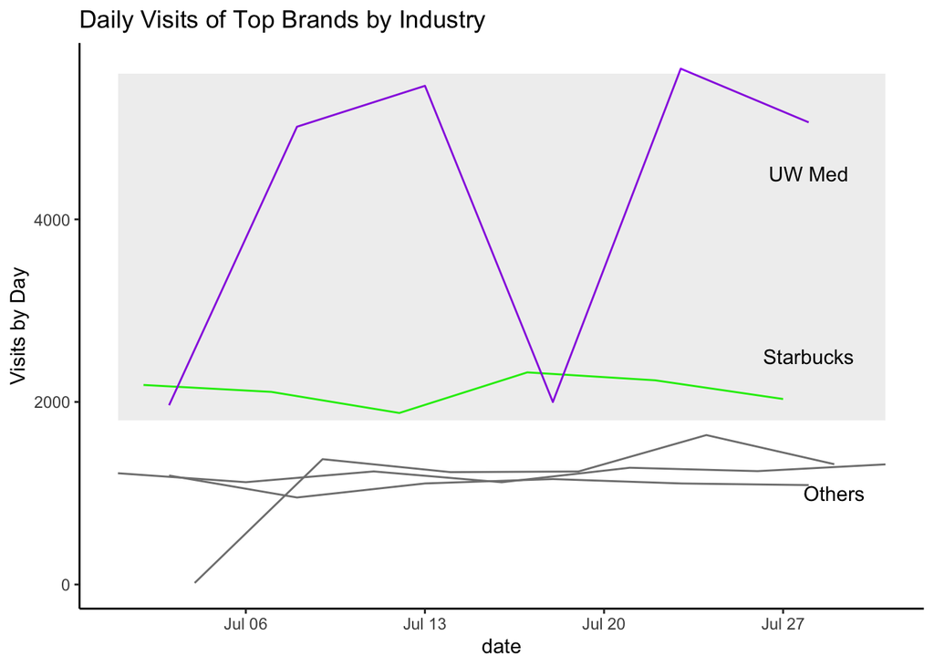

```r
dv %>% filter(brands == c('UW Medicine', 'Starbucks','Costco Wholesale Corp.', 'Safeway', 'McDonald\'s')) %>% ggplot(aes(x = date, y = visits_by_day, color = brands)) +geom_line(show.legend = FALSE) + scale_color_manual(values = c('UW Medicine' = 'purple', 'Starbucks' = 'green')) + annotate('text', x = as.Date ('2020-07-28'), y = 4500, label = 'UW Med') + annotate('text', x = as.Date('2020-07-28'), y = 2500, label = 'Starbucks') + annotate('text', x = as.Date('2020-07-29'), y = 1000, label = 'Others') + ylab('Visits by Day') + ggtitle('Daily Visits of Top Brands by Industry') + annotate("rect", xmin = as.Date('2020-07-01'), xmax = as.Date('2020-07-31'), ymin = 1800, ymax = 5600, alpha =.1 ) + theme_classic()
```

#### In UW Med’s industry, it is far above the competition for average daily visits.

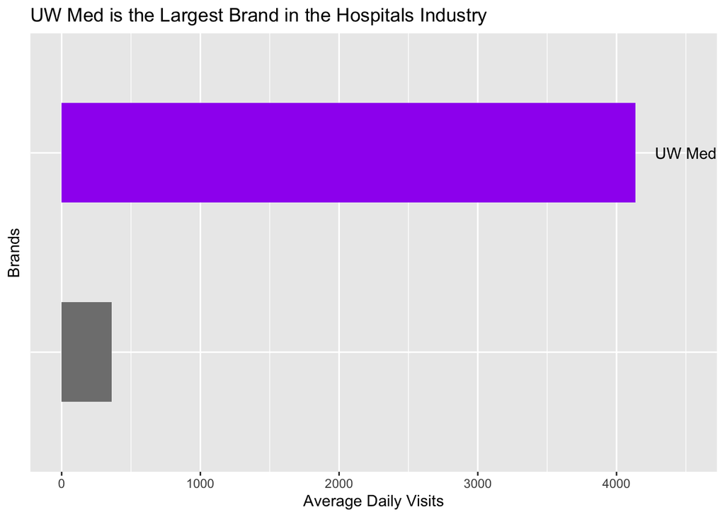

```r
dv %>% filter(naics_title == 'General Medical and Surgical Hospitals') %>% group_by(brands) %>% filter(row_number() ==1) %>% ggplot(aes(x = reorder(brands, avr_daily_visits), y = avr_daily_visits, fill = brands)) + geom_col(show.legend = FALSE, width = .5) + scale_fill_manual(values = c('UW Medicine' = 'purple'))  + coord_flip() + theme(axis.text.y = element_blank(), axis.ticks.y = element_blank()) + annotate('text', x = 'UW Medicine', y = 4500, label = 'UW Med') + xlab('Brands') + ylab('Average Daily Visits') + ggtitle('UW Med is the Largest Brand in the Hospitals Industry')
```

#### Starbucks is also far above the competition in average daily visits.

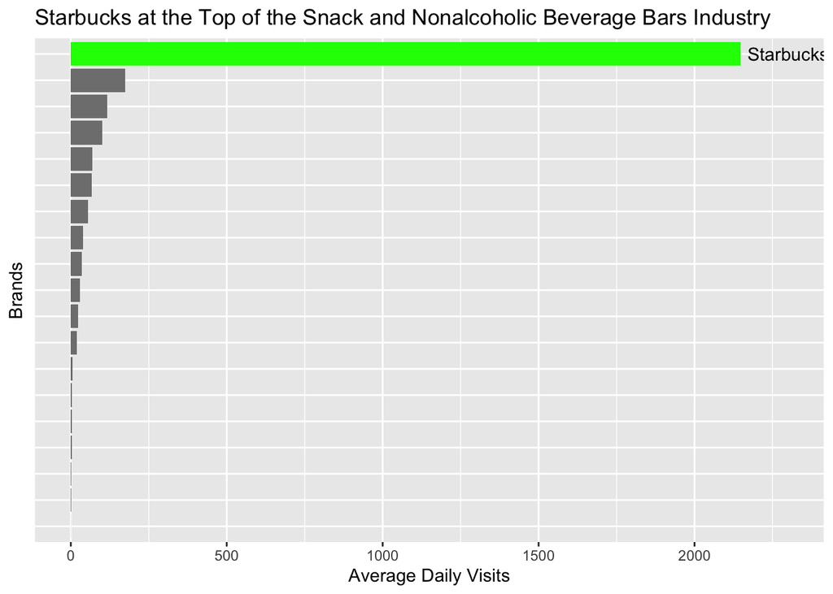

```r
dvsnack %>% filter(row_number() ==1) %>% filter(brands != 'Smaller Brands') %>% ggplot(aes(x = reorder(brands, avr_daily_visits), y = avr_daily_visits, fill = brands)) +geom_col(show.legend = FALSE) + scale_fill_manual(values = c('Starbucks' = 'green')) + coord_flip() + theme(axis.text.y = element_blank(), axis.ticks.y = element_blank()) + annotate('text', x = 'Starbucks', y = 2300, label = 'Starbucks') + xlab('Brands') + ylab('Average Daily Visits') + ggtitle('Starbucks at the Top of the Snack and Nonalcoholic Beverage Bars Industry')
```

#### This graph gives a further look into the trend line for daily visits in the hospital industry and how far above UW Med is from the competition.

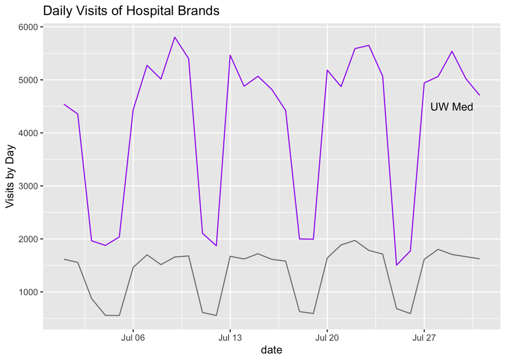

```r
dv %>% filter(naics_title == 'General Medical and Surgical Hospitals') %>% group_by(brands) %>% ggplot(aes(x = date, y = visits_by_day, color = brands)) +geom_line(show.legend = FALSE) + ylab('Visits by Day') + annotate('text', x = as.Date('2020-07-29'), y = 4500, label = 'UW Med') + scale_color_manual(values = c('UW Medicine' = 'purple')) + ggtitle('Daily Visits of Hospital Brands')
```

#### This graph gives a look into how the industry with Starbucks has much more consistent daily visits than UW Med and Starbucks is far above the competition.

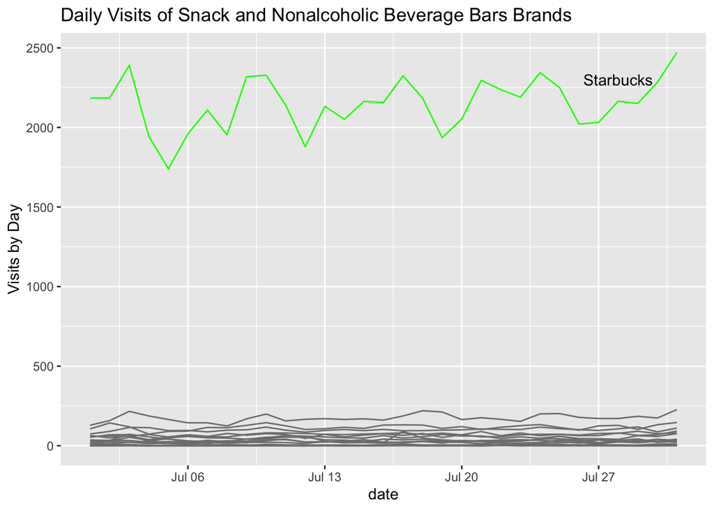

```r
dvsnack %>% filter(brands != 'Smaller Brands') %>% ggplot(aes(x = date, y = visits_by_day, color = brands)) +geom_line(show.legend = FALSE) + scale_color_manual(values = c('Starbucks' = 'green')) + annotate('text', x = as.Date('2020-07-28'), y = 2300, label = 'Starbucks') + ggtitle('Daily Visits of Snack and Nonalcoholic Beverage Bars Brands') + ylab('Visits by Day')
```